# Animint Tutorial

This tutorial is designed to demonstrate animint, a package that converts ggplot2 plots into d3 javascript graphics. Animint allows you to make interactive web-based graphics using familiar R methods. In addition, animint allows graphics to be animated and respond to user clicks.

## Contents

- Introduction
- Tornado Example - see what animint can do, including explanations of clickSelects, showSelected, and animations.
- Climate Example - another demonstration of using animint with multiple linked plots and animation.
- Examples of Geoms - explanations of how to use statistics and certain geoms in animint, demonstrations of most geoms that animint supports.
  - Lines
  - Points
  - Interactive Points - short introduction to clickSelects and showSelected with familiar geoms.
  - Other Geoms - abline, area, bar, contour, density,…  
    This section also includes discussions of problem statistics and some unimplemented geoms and how to get around them.

## Lines

### Simple lines

This should work exactly as in ggplot2.

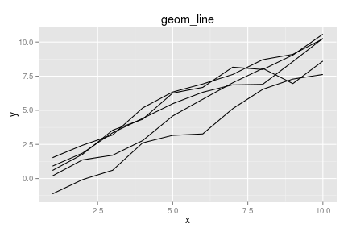

```r
#' Generate data
data <- data.frame(x=rep(1:10, times=5), group = rep(1:5, each=10))
data$lt <- c("even", "odd")[(data$group%%2+1)] # linetype
data$group <- as.factor(data$group)
data$y <- rnorm(length(data$x), data$x, .5) + rep(rnorm(5, 0, 2), each=10)

#' Simple line plot
p1 <- ggplot() + geom_line(data=data, aes(x=x, y=y, group=group)) +
  ggtitle("geom_line")
p1
```

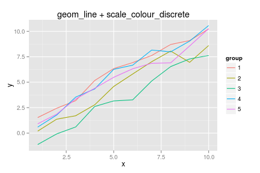

```r
#' Simple line plot with colours...
p2 <- ggplot() + geom_line(data=data, aes(x=x, y=y, colour=group, group=group)) +
  ggtitle("geom_line + scale_colour_discrete")
p2
```

```r
gg2animint(list(p1=p1, p2=p2), out.dir="geoms/linessimple")
```

Animint plot

### Linetypes

ggplot2 has several methods of linetype specification, all of which are supported in animint.

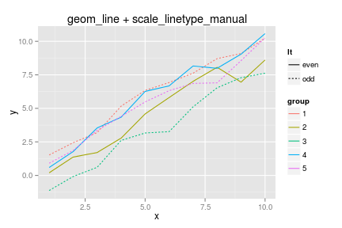

```r
#' Simple line plot with colours and linetype
p3 <- ggplot() + geom_line(data=data, aes(x=x, y=y, colour=group, group=group, linetype=lt)) +
  ggtitle("geom_line + scale_linetype_manual")
p3
```

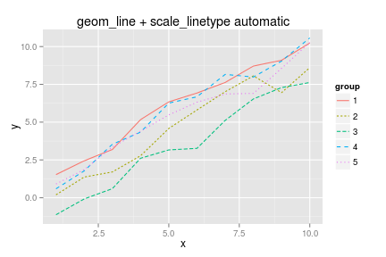

```r
#' Use automatic linetypes from ggplot with coerced factors
p4 <- ggplot() + geom_line(data=data, aes(x=x, y=y, colour=group, group=group, linetype=group)) +
  ggtitle("geom_line + scale_linetype automatic")
p4
```

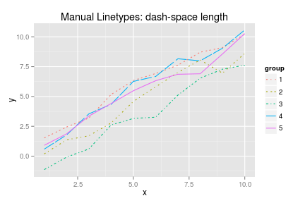

```r
#' Manually specify linetypes using <length, space, length, space...> notation
data$lt <- rep(c("2423", "2415", "331323", "F2F4", "solid"), each=10)
p5 <- ggplot() + geom_line(data=data, aes(x=x, y=y, colour=group, group=group, linetype=lt)) +
  scale_linetype_identity("group", guide="legend", labels = c("1", "2", "3", "4", "5")) +
  scale_colour_discrete("group") +
  ggtitle("Manual Linetypes: dash-space length")
p5
```

```r
#' All possible linetypes
lts <- scales::linetype_pal()(13)
lt1 <- data.frame(x=0, xend=.25, y=1:13, yend=1:13, lt=lts, lx = -.125)
p6 <- ggplot()+geom_segment(data=lt1, aes(x=x, xend=xend, y=y, yend=yend, linetype=lt)) +
  scale_linetype_identity() + geom_text(data=lt1, aes(x=lx, y=y, label=lt), hjust=0) +
  ggtitle("Scales package: all linetypes")

lts2 <- c("solid", "dashed", "dotted", "dotdash", "longdash", "twodash")
lt2 <- data.frame(x=0, xend=.25, y=1:6, yend=1:6, lt=lts2, lx=-.125)
p7 <- ggplot() + geom_segment(data=lt2, aes(x=x, xend=xend, y=y, yend=yend, linetype=lt)) +
  scale_linetype_identity() + geom_text(data=lt2, aes(x=lx, y=y, label=lt), hjust=0) +
  ggtitle("Named linetypes")

gg2animint(list(p3=p3, p4=p4, p5=p5, p6=p6, p7=p7), out.dir="geoms/linetypes")
```

Animint Plot

### Alpha scales and lines

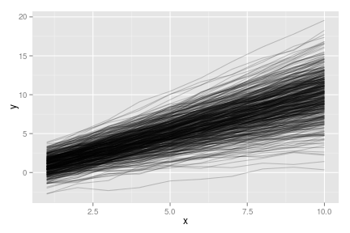

```r
#' Spaghetti Plot Data
n <- 500
pts <- 10
data2 <- data.frame(x=rep(1:pts, times=n), group = rep(1:n, each=pts))
data2$group <- as.factor(data2$group)
data2$y <- rnorm(length(data2$x), data2$x*rep(rnorm(n, 1, .25), each=pts), .25) + rep(rnorm(n, 0, 1), each=pts)
data2$lty <- "solid"
data2$lty[which(data2$group%in%subset(data2, x==10)$group[order(subset(data2, x==10)$y)][1:floor(n/10)])] <- "3133"
data2 <- ddply(data2, .(group), transform, maxy = max(y), miny=min(y))
data2$below0 <- factor(sign(data2$miny)<0)

qplot(data=data2, x=x, y=y, group=group, geom="line", alpha=I(.2))
```

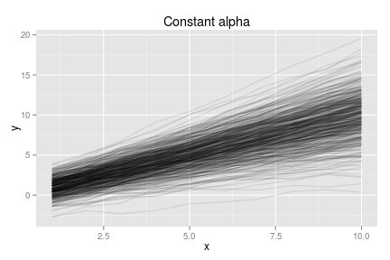

```r
#' scale_alpha
p8 <- ggplot() + geom_line(data=data2, aes(x=x, y=y, group=group), alpha=.1) +
  ggtitle("Constant alpha")
p8
```

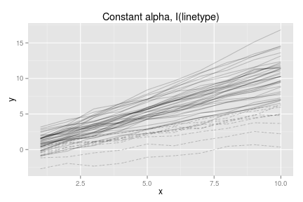

```r
p9 <- ggplot() + geom_line(data=subset(data2, as.numeric(group) < 50),
                           aes(x=x, y=y, group=group, linetype=lty), alpha=.2) +
  scale_linetype_identity() +
  ggtitle("Constant alpha, I(linetype)")
p9
```

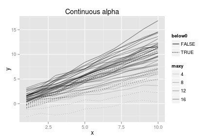

```r
p10 <- ggplot() + geom_line(data=subset(data2, as.numeric(group) < 50),
                            aes(x=x, y=y, group=group, linetype=below0, alpha=maxy)) +
  scale_alpha_continuous(range=c(.1, .5)) +
  ggtitle("Continuous alpha")
p10
```

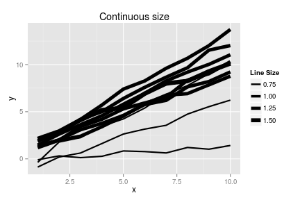

```r
#' Size Scaling
p11 <- ggplot() + geom_line(data=subset(data2, as.numeric(group)%%50 ==1),
                            aes(x=x, y=y, group=group, size=(floor(miny)+3)/3)) +
  scale_size_continuous("Line Size", range=c(1,3)) +
  ggtitle("Continuous size")
p11
```

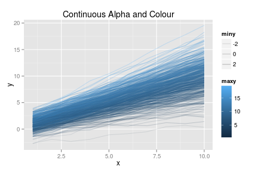

```r
p12 <- ggplot() + geom_line(data=data2, aes(x=x, y=y, group=group, alpha=miny, colour=maxy)) +
  scale_alpha_continuous(range=c(.1, .3)) +
  ggtitle("Continuous Alpha and Colour")
p12
```

```r
gg2animint(list(p8=p8, p9=p9, p10=p10, p11=p11, p12=p12), out.dir="geoms/alphalines")
```

Animint plot

## Points

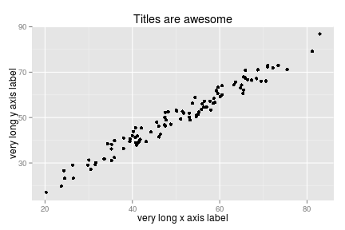

```r
# Randomly generate some data
scatterdata <- data.frame(x=rnorm(100, 50, 15))
scatterdata$y <- with(scatterdata, runif(100, x-5, x+5))
scatterdata$xnew <- round(scatterdata$x/20)*20
scatterdata$xnew <- as.factor(scatterdata$xnew)
scatterdata$class <- factor(round(scatterdata$x/10)%%2, labels=c("high", "low"))
scatterdata$class4 <- factor(rowSums(sapply(quantile(scatterdata$x)+c(0,0,0,0,.1), function(i) scatterdata$x<i)), levels=1:4, labels=c("high", "medhigh", "medlow", "low"), ordered=TRUE)

s1 <- ggplot() + geom_point(data=scatterdata, aes(x=x, y=y)) +
  xlab("very long x axis label") +
  ylab("very long y axis label") +
  ggtitle("Titles are awesome")
s1
```

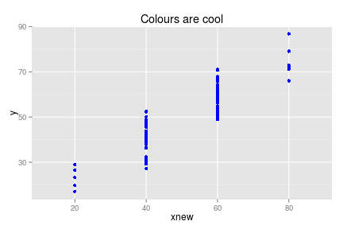

```r
#' Colours, Demonstrates axis -- works with factor data
#' Specify colours using R colour names
s2 <- ggplot() + geom_point(data=scatterdata, aes(x=xnew, y=y), colour="blue") +
  ggtitle("Colours are cool")
s2
```

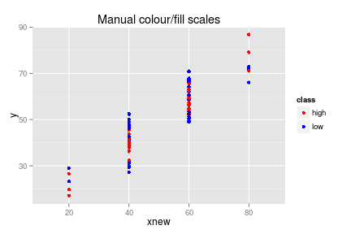

```r
#' Specify colours manually using hex values
s3 <- ggplot() +
  geom_point(data=scatterdata, aes(x=xnew, y=y, colour=class, fill=class)) +
  scale_colour_manual(values=c("#FF0000", "#0000FF")) +
  scale_fill_manual(values=c("#FF0000", "#0000FF")) +
  ggtitle("Manual colour/fill scales")
s3
```

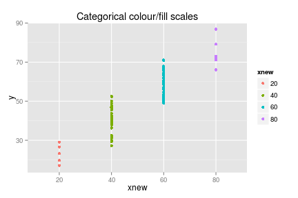

```r
#' Categorical colour scales
s4 <- ggplot() + geom_point(data=scatterdata, aes(x=xnew, y=y, colour=xnew, fill=xnew)) +
  ggtitle("Categorical colour/fill scales")
s4
```

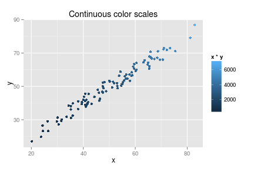

```r
#' Color by x*y axis (no binning)
s6 <- ggplot() + geom_point(data=scatterdata, aes(x=x, y=y, color=x*y, fill=x*y)) +
  ggtitle("Continuous color scales")
s6
```

```r
gg2animint(list(s1=s1, s2=s2, s3=s3, s4=s4, s6=s6), out.dir="geoms/simplepoints")
```

Animint plot

### **geom_jitter**

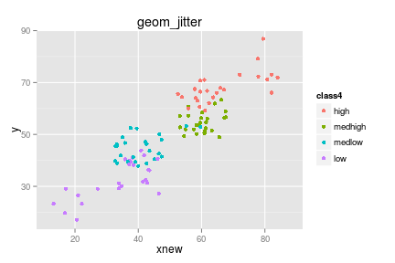

```r
s5 <- ggplot() + geom_jitter(data=scatterdata, aes(x=xnew, y=y, colour=class4, fill=class4)) +
  ggtitle("geom_jitter")
s5
```

```r
gg2animint(list(s5=s5), out.dir="geoms/jitterpoints")
```

Animint plot

### Interactive plots and scale_size

With showSelected, it is sometimes useful to have two copies of a geom - one copy with low alpha that has no showSelected or clickSelects attributes, and another copy that is interactive. This allows the data to be visible all the time while still utilizing the interactivity of d3.

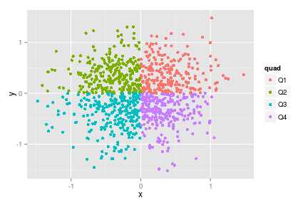

```r
library(plyr)
scatterdata2 <- data.frame(x=rnorm(1000, 0, .5), y=rnorm(1000, 0, .5))
scatterdata2$quad <- c(3, 4, 2, 1)[with(scatterdata2, (3+sign(x)+2*sign(y))/2+1)]
scatterdata2$quad <- factor(scatterdata2$quad, labels=c("Q1", "Q2", "Q3", "Q4"), ordered=TRUE)
scatterdata2 <- ddply(scatterdata2, .(quad), transform, str=sqrt(x^2+y^2)/4)
scatterdata2.summary <- ddply(scatterdata2, .(quad), summarise, xmin=min(x), xmax=max(x), ymin=min(y), ymax=max(y), xmean=mean(x), ymean=mean(y))
qplot(data=scatterdata2, x=x, y=y, geom="point", colour=quad)
```

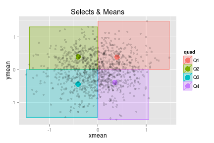

```r
#' Interactive plots...
s7 <- ggplot() +
  geom_rect(data=scatterdata2.summary, aes(xmax=xmax, xmin=xmin, ymax=ymax, ymin=ymin,
                                           colour=quad, fill=quad,
                                           clickSelects = quad), alpha=.3) +
  geom_point(data=scatterdata2.summary, aes(x=xmean, y=ymean, colour=quad, fill=quad, showSelected = quad), size=5) +
  geom_point(data=scatterdata2, aes(x=x, y=y), alpha=.15) +
  scale_colour_discrete(guide="legend") + scale_fill_discrete(guide="legend") +
  scale_alpha_discrete(guide="none") +
  ggtitle("Selects & Means")
s7
```

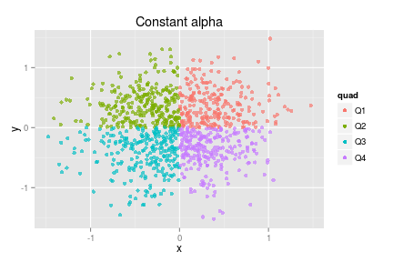

```r
#' Single alpha value
s8 <- ggplot() +
  geom_point(data=scatterdata2, aes(x=x, y=y, colour=quad, fill=quad),alpha=.2)+
  geom_point(data=scatterdata2, aes(x=x, y=y, colour=quad, fill=quad,
                                    clickSelects=quad, showSelected=quad), alpha=.6) +
  guides(colour = guide_legend(override.aes = list(alpha = 1)),
         fill = guide_legend(override.aes = list(alpha = 1))) +
  ggtitle("Constant alpha")
s8
```

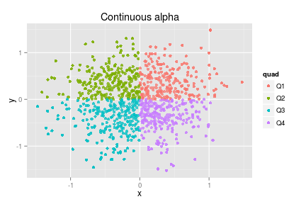

```r
#' Continuous alpha
s9 <- ggplot() +
  geom_point(data=scatterdata2, aes(x=x, y=y, colour=quad, fill=quad),alpha=.2)+
  geom_point(data=scatterdata2, aes(x=x, y=y, colour=quad, fill=quad,
                                    alpha=str, clickSelects=quad, showSelected=quad)) +
  guides(colour = guide_legend(override.aes = list(alpha = 1)),
         fill = guide_legend(override.aes = list(alpha = 1))) +
  scale_alpha(range=c(.6, 1), guide="none") +
  ggtitle("Continuous alpha")
s9
```

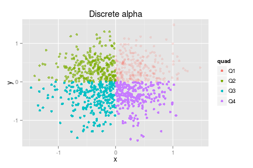

```r
#' Categorical alpha and scale_alpha_discrete()
#' Note, to get unselected points to show up, need to have two copies of geom_point: One for anything that isn't selected, one for only the selected points.
s10 <- ggplot() +
  geom_point(data=scatterdata2, aes(x=x, y=y, colour=quad, fill=quad, alpha=quad))+
  geom_point(data=scatterdata2, aes(x=x, y=y, colour=quad, fill=quad,
                                    alpha=quad, clickSelects=quad, showSelected=quad)) +
  guides(colour = guide_legend(override.aes = list(alpha = 1)),
         fill = guide_legend(override.aes = list(alpha = 1))) +
  scale_alpha_discrete(guide="none")+
  ggtitle("Discrete alpha")
s10
```

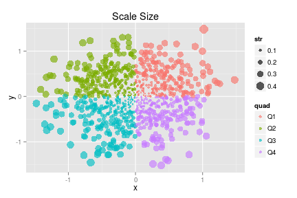

```r
#' Point Size Scaling
#' Scale defaults to radius, but area is more easily interpreted by the brain (Tufte).
s11 <- ggplot() +
  geom_point(data=scatterdata2, aes(x=x, y=y, colour=quad, fill=quad, size=str), alpha=.5) +
  geom_point(data=scatterdata2, aes(x=x, y=y, colour=quad, fill=quad,
                                    size=str, clickSelects=quad, showSelected=quad), alpha=.3) +
  ggtitle("Scale Size")
s11
```

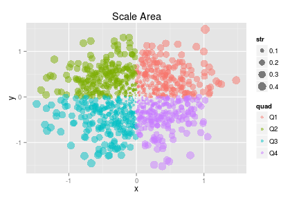

```r
s12 <- ggplot() +
  geom_point(data=scatterdata2, aes(x=x, y=y, colour=quad, fill=quad, size=str), alpha=.5) +
  scale_size_area() +
  ggtitle("Scale Area")
s12
```

```r
gg2animint(list(s7=s7, s8=s8, s9=s9, s10=s10, s11=s11, s12=s12), out.dir="geoms/interactivepoints")
```

Animint plots

## Other geoms

```r
library(ggplot2)
library(plyr)
library(animint)
```

### geom_abline

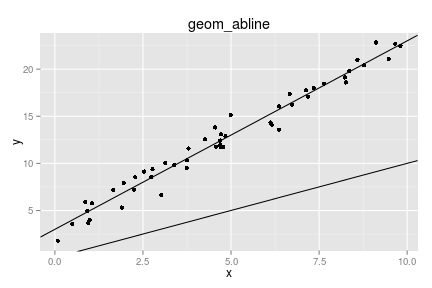

```r
xydata <- data.frame(x=sort(runif(50, 0, 10)))
xydata$y <- 3+2*xydata$x + rnorm(50, 0, 1)
g1 <- ggplot() + geom_point(data=xydata, aes(x=x, y=y)) +
  geom_abline(data=data.frame(intercept=c(3, 0), slope=c(2,1)), aes(intercept=intercept, slope=slope)) +
  ggtitle("geom_abline")
g1
```

```r
gg2animint(list(g1=g1), out.dir="geoms/abline")
```

Animint plot

### geom_ribbon

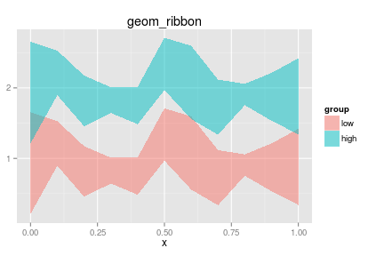

```r
ribbondata <- data.frame(x=seq(0, 1, .1), ymin=runif(11, 0, 1), ymax=runif(11, 1, 2))
ribbondata <- rbind(cbind(ribbondata, group="low"), cbind(ribbondata, group="high"))
ribbondata[12:22,2:3] <- ribbondata[12:22,2:3]+1
g2 <- ggplot() +
  geom_ribbon(data=ribbondata, aes(x=x, ymin=ymin, ymax=ymax, group=group, fill=group), alpha=.5) +
  ggtitle("geom_ribbon")
g2
```

```r
gg2animint(list(g2=g2), out.dir="geoms/ribbon")
```

Animint plot

### geom_tile

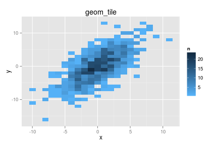

```r
tiledata <- data.frame(x=rnorm(1000, 0, 3))
tiledata$y <- rnorm(1000, tiledata$x, 3)
tiledata$rx <- round(tiledata$x)
tiledata$ry <- round(tiledata$y)
tiledata <- ddply(tiledata, .(rx,ry), summarise, n=length(rx))

g3 <- ggplot() + geom_tile(data=tiledata, aes(x=rx, y=ry, fill=n)) +
  scale_fill_gradient(low="#56B1F7", high="#132B43") +
  xlab("x") + ylab("y") + ggtitle("geom_tile")
g3
```

```r
gg2animint(list(g3=g3), out.dir="geoms/tile")
```

Animint plot

### geom_path

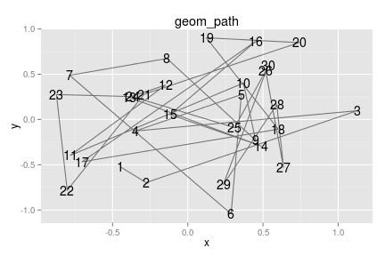

```r
pathdata <- data.frame(x=rnorm(30, 0, .5), y=rnorm(30, 0, .5), z=1:30)
g4 <- ggplot() + geom_path(data=pathdata, aes(x=x, y=y), alpha=.5) +
  geom_text(data=pathdata, aes(x=x, y=y, label=z)) +
  ggtitle("geom_path")
g4
```

```r
gg2animint(list(g4=g4), out.dir="geoms/path")
```

Animint plot

### geom_polygon

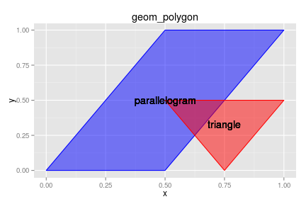

```r
polydata <- rbind(
  data.frame(x=c(0, .5, 1, .5, 0), y=c(0, 0, 1, 1, 0), group="parallelogram", fill="blue", xc=.5, yc=.5),
  data.frame(x=c(.5, .75, 1, .5), y=c(.5, 0, .5, .5), group="triangle", fill="red", xc=.75, yc=.33)
  )
g5 <- ggplot() +
  geom_polygon(data=polydata, aes(x=x, y=y, group=group, fill=fill, colour=fill), alpha=.5)+
  scale_colour_identity() + scale_fill_identity()+
  geom_text(data=polydata, aes(x=xc, y=yc, label=group)) +
  ggtitle("geom_polygon")
g5
```

```r
gg2animint(list(g5=g5), out.dir="geoms/polygon")
```

Animint plot

### geom_linerange

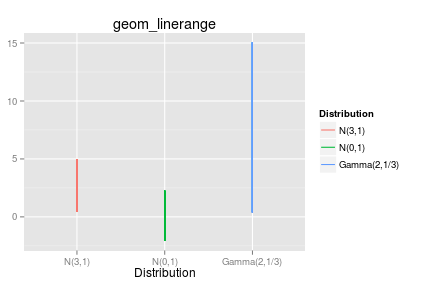

```r
boxplotdata <- rbind(data.frame(x=1:50, y=sort(rnorm(50, 3, 1)), group="N(3,1)"),
                     data.frame(x=1:50, y=sort(rnorm(50, 0, 1)), group="N(0,1)"),
                     data.frame(x=1:50, y=sort(rgamma(50, 2, 1/3)), group="Gamma(2,1/3)"))
boxplotdata <- ddply(boxplotdata, .(group), transform, ymax=max(y), ymin=min(y), med=median(y))

g6 <- ggplot() +
  geom_linerange(data=boxplotdata, aes(x=factor(group), ymax=ymax, ymin=ymin, colour=factor(group))) +
  ggtitle("geom_linerange") + scale_colour_discrete("Distribution") + xlab("Distribution")
g6
```

```r
gg2animint(list(g6=g6), out.dir="geoms/linerange")
```

Animint plot

### geom_histogram

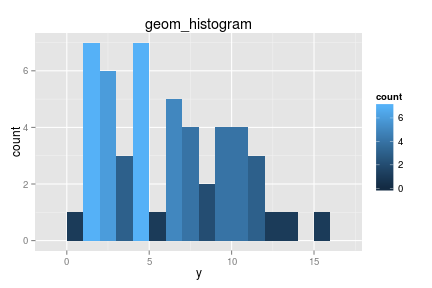

```r
g7 <- ggplot() +
  geom_histogram(data=subset(boxplotdata, group=="Gamma(2,1/3)"), aes(x=y, fill=..count..), binwidth=1) +
  ggtitle("geom_histogram")
g7
```

```r
gg2animint(list(g7=g7), out.dir="geoms/histogram")
```

Animint plot